# Proseminar Arbeit

Lino Moser

2023-01-06

## **Veränderung der Erwerbsmodelle in Schweizer Familien**

Die Arbeitsaufteilung in Schweizer Familien ist seit längerem ein politisches und gesellschaftliches Diskusionsthema. Das Bundesamt für Statsitik stellt auf seiner Website Daten zu den Erwerbsmodellen von schweizer Familien zur Verfügung, die im Zuge der Schweizer Arbeitskräfterhebung seit dem Jahr 1992 erhoben werden ([Datensatz 1](https://www.bfs.admin.ch/asset/de/22784588), [Datensatz 2](https://www.bfs.admin.ch/asset/de/325794)).

Anhand von diesen Daten möchte ich folgende Frage beantworten:

Veränderte sich die Verteilung der Erwerbsmodelle in Schweizer Familien auf eine bedeutungsvolle Weise seit 1992? Ich gehe dabei von einer generellen Entwicklung hin zu von mehr Teil- und Vollzeit- Arbeit der Partnerin und weniger Vollzeit Arbeit des Partners aus.

In untenstehender Grafik ist die grobe Veränderung in den Erwerbsmodellen in drei Gruppen dargestellt:

1. *Erwerbsmodelle zusammengefasst, in denen Partnerin und Partner beide Vollzeit oder Teilzeit arbeiten*
2. *Alle Modelle zusammengefasst, in denen der Partner Vollzeit arbeitet und die Partnerin weniger oder gar nicht arbeitet*
3. *Alle Erwerbsmodelle zusammengefasst, in denen die Partnerin Vollzeit und der Partner weniger oder gar nicht arbeitet*

### Arbeitsaufteilung in Schweizer Familien:

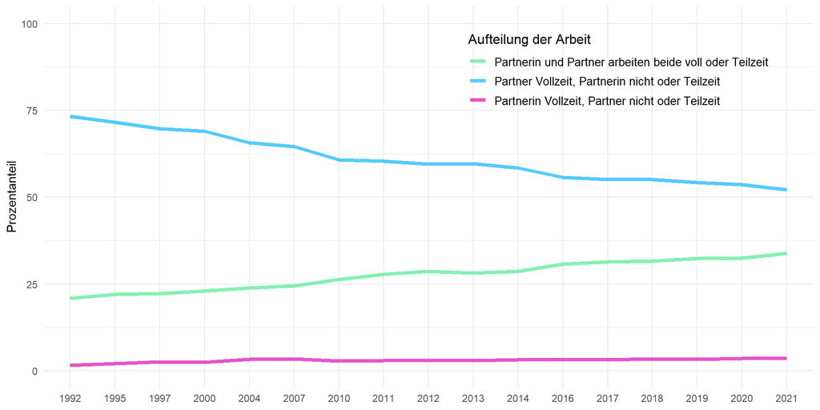

Aus dieser Darstellung wird ersichtlich, dass sich mindestens seit 1992 eine konstante Veränderung in den Erwerbsmodellen zeigt. Erwerbsmodelle in denen der Partner Vollzeit arbeitet und die Partnerin nicht oder Teilzeit arbeitet nehmen insgesamt ab. Die Modelle mit gemeinsamer Vollzeit oder Teilzeit Arbeit nehmen insgesamt zu. Die Erwerbsmodelle in denen die Partnerin mehr arbeitet als der Partner nehmen nur ganz leicht zu (etwa um 2% seit 1992).

Um die drei Kategorien aus der Grafik oben noch etwas genauer zu betrachten, sind sie in den Grafiken unten aufgegliedert. Die Farben der Reiter geben an, welche Kategorie aufgegliedert wurde (unter dem blauen Reiter ist zB. eine Grafik mit den Modellen, aus denen die blaue Linie im oberen Graph zusammengesetzt ist. Wenn man die Werte für jedes Jahr zusammenrechnen würde, erhielte man die blaue Linie aus der ersten Grafik). Unter den Grafiken ist jeweils ein kleiner Text, der die Grafik erklärt.

### Aufgliederung der drei Kategorien:

#### Beide Teilzeit/Vollzeit

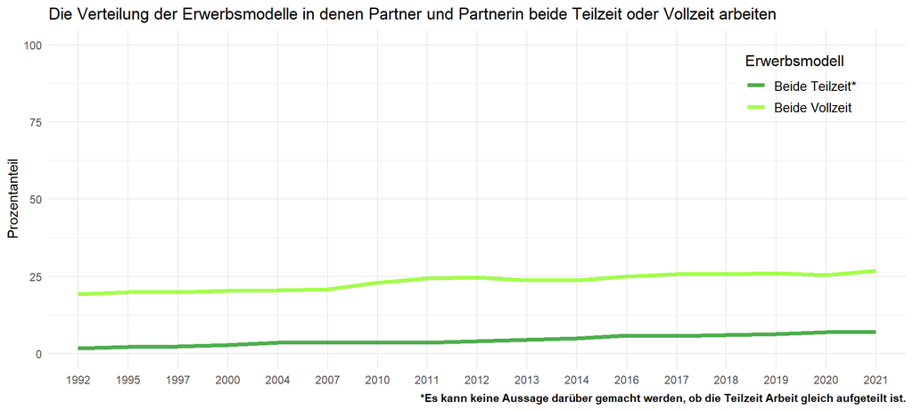

#### Partner Vollzeit, Partnerin weniger

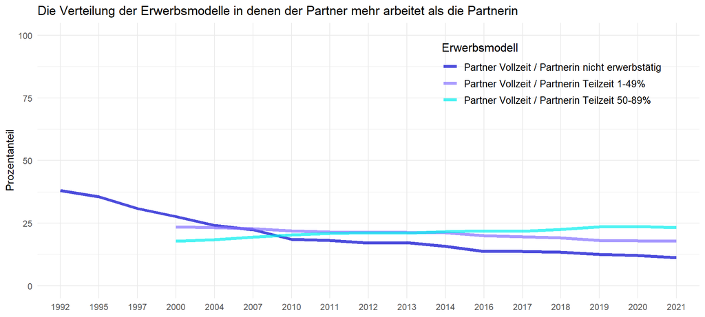

In dieser Grafik können wir gut sehen, dass die Partnerinnen über die Jahre hinweg zunehmend mehr Teilzeit Prozente arbeiten. Die Modelle in denen die Partnerinnen nicht arbeiten oder weniger als 50% arbeiten nehmen ab und das Modell in dem die Partnerin über 50% Teilzeit arbeitet nimmt zu. Es zeigt sich also eine Veränderung hin zu mehr Arbeitsprozenten der Partnerin.

#### Partnerin Vollzeit, Partner weniger

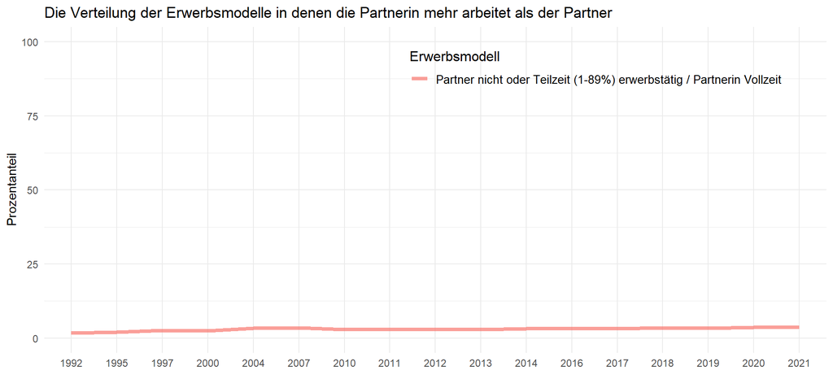

Die Modelle in denen die Partnerin vollzeit arbeitet und der Partner weniger arbeitet nahmen über die Zeit hinweg minimal zu (ca. 2%). Es haben aber zu wenig Paare dieses Erwerbsmodell, um es feiner zu unterteilen.

Durch die Aufgliederung wird erkennbar, dass gemeinsame Vollzeit- und Teilzeit- Arbeit über die Jahre hinweg je etwa gleich viel zunahmen. In den Modellen in denen der Partner Vollzeit und die Partnerin nicht oder Teilzeit arbeitet gibt es ingsgesammt eine Abnahme. Gleichzeitig zeigt sich bei genauerem Betrachten eine Veränderung hin zu mehr Erwerbsprozenten der Partnerin und weg von wenig oder gar keiner Teilzeit- Arbeit der Partnerin.

Die Hypothese, dass sich die Erwerbsmodelle hin zu mehr Erwerbsprozenten der Partnerin entwickelten wird durch die Daten unterstützt. Ob der Partner weniger Vollzeit arbeitet ist hingegen nicht klar ersichtlich. Zwar nehmen die Erwerbsmodelle in denen der Partner Vollzeit und die Partnerin Teilzeit arbeiten generell ab (erste Grafik), es ist aber möglich, dass diese Abnahme durch eine Zunahme der Erwerbsmodelle zu erklären ist, in denen Partnerin und Partner beide Vollzeit arbeiten.

### Welchen Einfluss hat das alter des jüngsten Kindes? (Zusatzfrage)

Das Alter eines Kindes in der Familie spielt eine Rolle, wenn es darum geht die Arbeit aufzuteilen. Ich nehme an, dass das Alter des Kindes über die Jahre hinweg mehr Einfluss auf die Erwerbsmodelle bekam, da ich davon ausgehe, dass der wiedereinstieg in die Berufswelt nach der Geburt eines Kindes über die Zeit hinweg einfacher wurde. Es sollte also in Erwerbsmodellen in denen die Partnerin arbeitet einen mit der Zeit zunehmenden Unterschied zwischen Familien geben die ein junges und Familien die ein älteres Kind haben (Bezüglich wie viele Prozent der Familien ein Erwerbsmodell haben in dem die Partnerin arbeitet).

In den Untestehenden Grafiken, ist aufgezeigt, wie sich die Erwerbsmodelle in Familien mit einem jungen jüngsten Kind und in Familien mit einem älteren jüngsten Kind über die Jahre hinweg entwickelt haben. Die Titel der Grafiken haben die Farbe der Linien in den oberen Grafiken. So kann man die allgemeine Entwicklungen aus der oberen Grafik mit der Entwicklung unter Einbezug des Alters des jüngsten Kindes in den Familien vergleichen.

### Erwerbsmodelle bei Familien mit jungen Kindern und älteren Kindern

#### Beide Teilzeit/Vollzeit

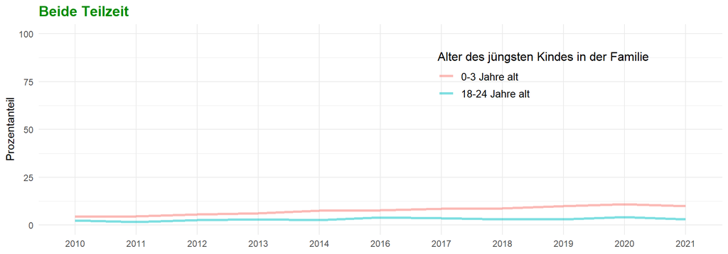

In der ersten Grafik ist ersichtlich, dass der Anteil der Familien in denen Partnerin und Partner Teilzeit arbeiten in Familien mit jungen Kindern höher ist als in Familien mit älteren Kindern. Der Einfluss des Alter des Kindes nahm über die Zeit hinweg zu.

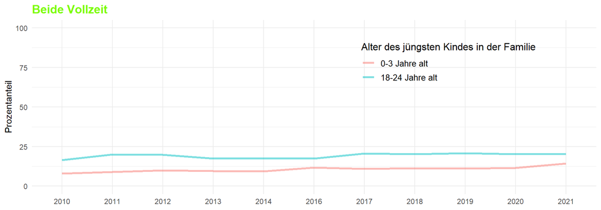

In der zweiten Grafik zeigt sich ein umgekehrtes Bild: Der Anteil der Familien in denen Partner und Partnerin Vollzeit arbeiten ist in Familien mit älteren Kindern höher als in Familien mit jüngeren Kindern. Der Einfluss des Alters des jüngsten Kindes schwankte über die Zeit hinweg.

#### Partner Vollzeit, Partnerin weniger

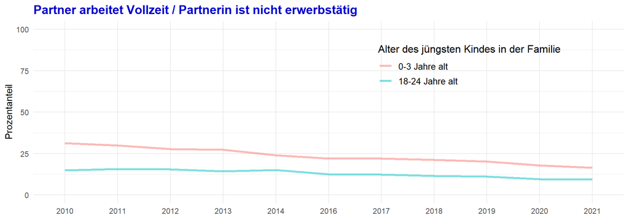

In der ersten Grafik ist zu erkennen, dass das Erwerbsmodell bei Familien mit ältern und jüngeren jüngsten Kindern abnahm. Die Abnahme ist aber stärker in der Gruppe der Familien mit einem jungen jüngsten Kind. Das Modell ist in Familien mit einem jüngeren jüngsten Kind immer noch häufiger als in Familien mit einem älteren jüngsten Kind. Der Einfluss des Alters des jüngsten Kindes nahm also ab.

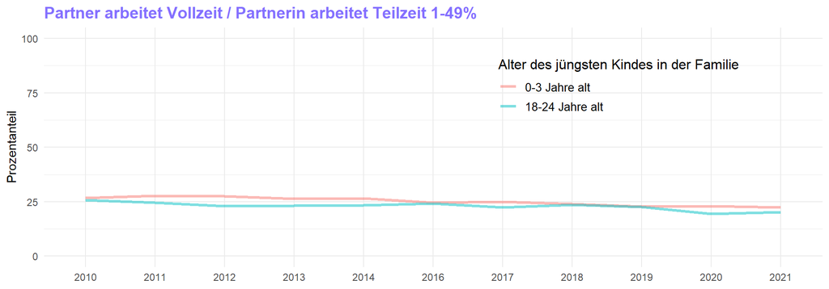

In der zweiten Grafik ist ersichlich, dass der Einfluss des Alters des jüngsten Kindes auf dieses Erwerbsmodell über die Jahre hinweg etwa gleich blieb. Von den Familien die ein älteres jüngstes Kind haben haben etwa gleiche viele dieses Erwerbsmodell wie in den Familien mit einem jüngern Kind.

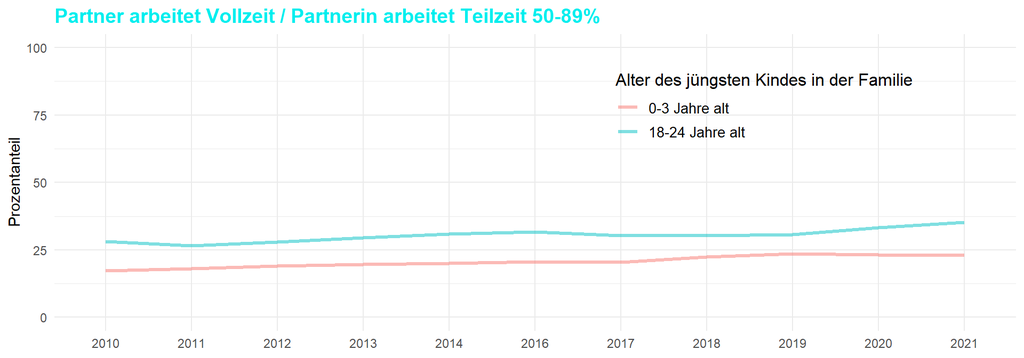

In der dritten Grafik zeigt sich das umgekehrte Bild der ersten Grafik. Das Erwerbsmodell nahm über die Jahre in beiden Gruppen generell zu. Der Anstieg ist für Familien mit jungem jüngstem Kind und älterem jüngsten Kind in etwa gleich. Im Gegensatz zu der ersten Grafik ist das Modell aber häufiger in Familien, die ein älteres jüngstes Kind haben.

#### Partnerin Vollzeit, Partner weniger

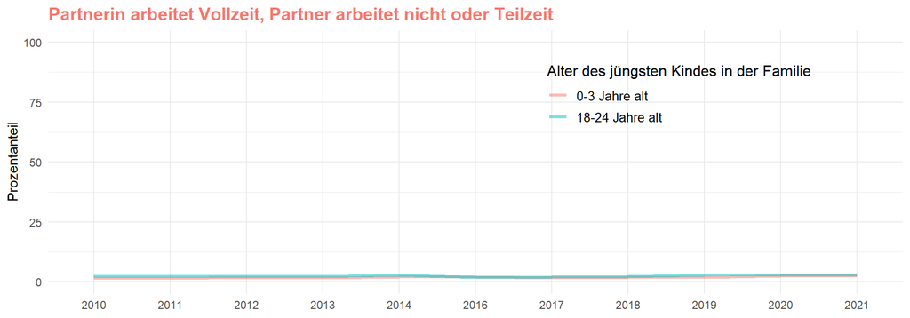

Der Einfluss des Alters des jüngsten Kindes ist in dieser Grafik schwer zu interpretieren, das Erwerbsmodell in Familien mit Kindern praktisch nicht vertreten ist. Es kann deshalb keine Aussage über die Verännderung gemacht werden.

Meine Hypothese muss abgelehnt werden, da die Daten je nach Modell in dem die Partnerin arbeitet nicht einheitlich in eine Richtung gehen.

Es ist interessant zu sehen, dass Erwerbsmodelle in denen die Partnerin mehr Arbeitet (Beide Vollzeit, Partnerin 50-89%) in Familien mit älterem jüngsten Kind häufiger vertreten sind als in Familien mit jungem jüngsten Kind. Erwerbsmodelle in denen die Partnerin gar nicht arbeitet sind bei Familien mit jüngerem jüngsten Kind jedoch häufiger vertreten als bei Familien mit älterem jüngsten Kind. Das Alter des jüngsten Kindes hat also einen Einfluss auf die Art der Erwerbsmodelle.

### **Der Untergang des modernen Mannes**

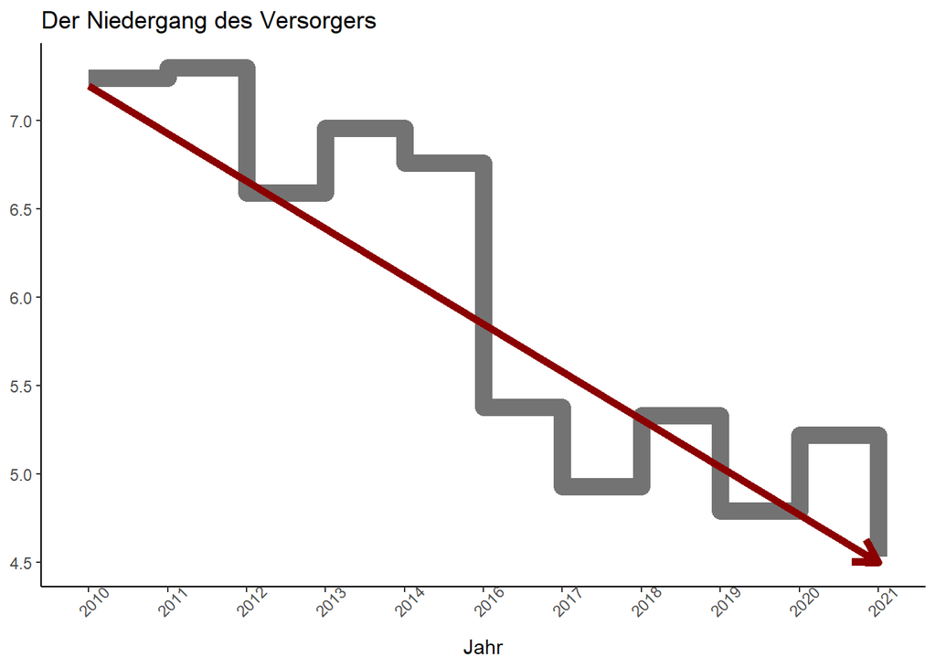

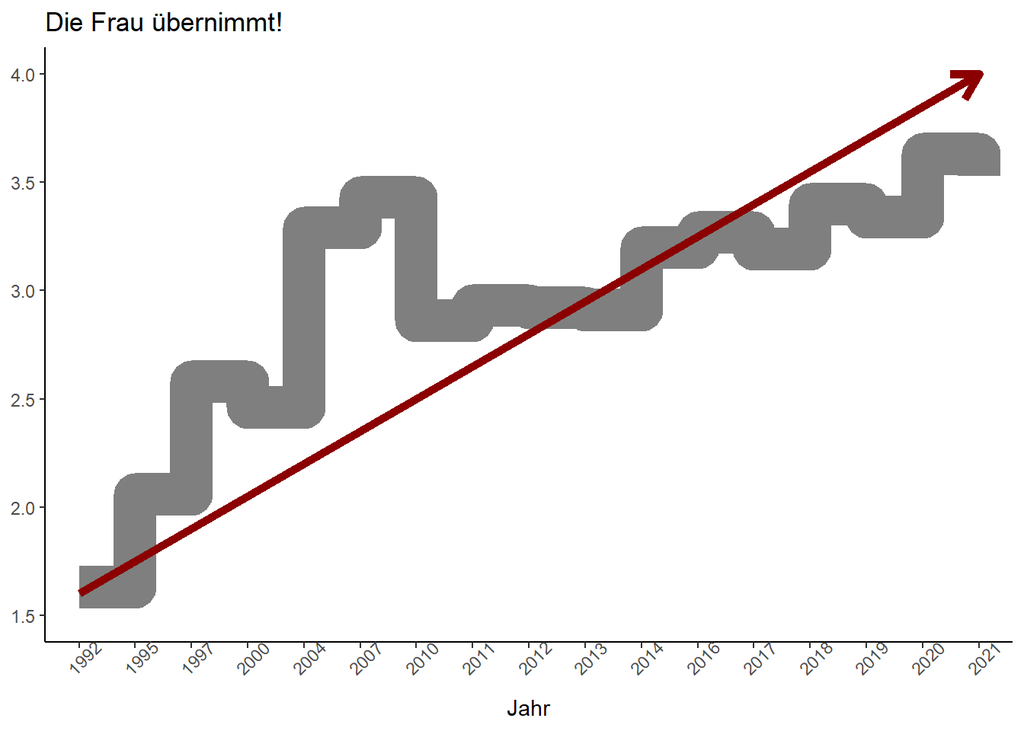

**Um diesen katastrophalen Trend aufzuhalten und die klassische Familie zu retten bitten wir deshalb zur Unterzeichnung unserer Petition zur “Rettung der schweizer Moral” .**